# Cookbook

Jeremy Wildfire

2022-04-08

# Cookbook Vignette

This vignette contains a series of examples showing how to initialize the safetyGraphics Shiny app in different scenarios.

# Overview

Most of the customization shown here is done by changing 4 key parameters in the `safetyGraphicsApp()` function:

- `domainData` – Domain-level Study Data
- `mapping` – List identifying the key columns/fields in your data
- `charts` – Define the charts used in the app.
- `meta` – Metadata table with info about required columns and fields

`domainData` and `mapping` generally change for every study, while `charts` and `meta` can generally be re-used across many studies.

The examples here are generally provided with minimal explanation. For a more detailed discussion of the logic behind these examples see the Chart Configuration Vignette or our [2021 R/Pharma Workshop](https://github.com/SafetyGraphics/RPharma2021-Workshop)

# Setup and installation

safetyGraphics requires R v4 or higher. These examples have been tested using RStudio v1.4, but should work on other platforms with proper configuration.

You can install `{safetyGraphics}` from CRAN like any other R package:

```
install.packages("safetyGraphics")
library("safetyGraphics")
```

Or to use the most recent development version from GitHub, call:

```
devtools::install_github("safetyGraphics/safetyCharts", ref="dev")
library(safetyCharts)
devtools::install_github("safetyGraphics/safetyGraphics", ref="dev")
library(safetyGraphics)
safetyGraphics::safetyGraphicsApp()
```

## Example 1 - Default App

To run the app with no customizations using sample AdAM data from the {safetyData} package, install the package and run:

```
safetyGraphics::safetyGraphicsApp()
```

# Loading Custom Data

The next several examples focus on study-specific customizations for loading and mapping data.

## Example 2 - SDTM Data

The data passed in to the safetyGraphics app can be customized using the `domainData` parameter in `safetyGraphicsApp()`. For example, to run the app with SDTM data saved in `{safetyData}`, call:

```
sdtm <- list(
    dm=safetyData::sdtm_dm,
    aes=safetyData::sdtm_ae,
    labs=safetyData::sdtm_lb
)

safetyGraphics::safetyGraphicsApp(domainData=sdtm)
```

## Example 3 - Single Data Domain

Running the app for a single data domain, is similar:

```
justLabs <- list(labs=safetyData::adam_adlbc)
safetyGraphics::safetyGraphicsApp(domainData=justLabs)
```

Note that charts with missing data are automatically dropped and the filtering tab is not present since it requires demographics data by default.

## Example 4 - Loading other data formats

Users can also import data from a wide-variety of data formats using standard R workflows and then initialize the app. The example below initializes the app using lab data saved as a sas transport file (.xpt)

```
xptLabs <- haven::read_xpt('https://github.com/phuse-org/phuse-scripts/blob/master/data/adam/cdiscpilot01/adlbc.xpt?raw=true')
safetyGraphics::safetyGraphicsApp(domainData=list(labs=xptLabs))
```

## Example 5 - Non-standard data

Next, let’s initialize the the app with non-standard data. {safetyGraphics} automatically detects AdAM and SDTM data when possible, but for non-standard data, the user must provide a data mapping. This can be done in the app using the data/mapping tab, or can be done when the app is initialized by passing a `mapping` list to `safetyGraphicsApp()`. For example:

```
notAdAM <- list(labs=safetyData::adam_adlbc %>% rename(id = USUBJID))
idMapping<- list(labs=list(id_col="id"))
safetyGraphicsApp(domainData=notAdAM, mapping=idMapping)
```

## Example 6 - Non-standard data #2

For a more realistic example, consider [this labs data set (csv)](https://raw.githubusercontent.com/SafetyGraphics/SafetyGraphics.github.io/master/pilot/SampleData_NoStandard.csv). The data can be loaded in to safetyGraphics with the code below, but several items in the mapping page need to be filled in:

```
labs <- read.csv("https://raw.githubusercontent.com/SafetyGraphics/SafetyGraphics.github.io/master/pilot/SampleData_NoStandard.csv")
safetyGraphics::safetyGraphicsApp(domainData=list(labs=labs))
```

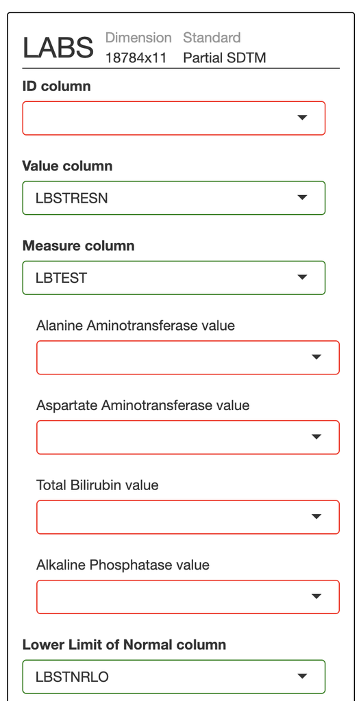

Fortunately there is no need to re-enter this mapping information in every time you re-start the app. After filling in these values once, you can export code to restart the app *with the specified settings pre-populated*. First, click on the setting icon in the header and then on “code” to see this page:

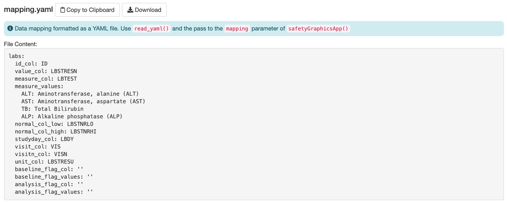

The YAML code provided here captures the updates you’ve made on the mapping page. To re-start the app with those settings, just save these YAML code in a new file called `customSettings.yaml` in your working directory, and then call:

```
labs <- read.csv("https://raw.githubusercontent.com/SafetyGraphics/SafetyGraphics.github.io/master/pilot/SampleData_NoStandard.csv")
customMapping <- read_yaml("customSettings.yaml")
safetyGraphics::safetyGraphicsApp(
    domainData=list(labs=labs),
    mapping=customMapping
)
```

Note, that for more complex customizations, the setting page also provides a `.zip` file with a fully re-usable version of the app.

# Custom Charts

The remaining examples focus on creating charts that are reusable across many studies. For extensive details on adding and customizing different types of charts, see this vignette.

## Example 7 - Drop Unwanted Charts

Users can also generate a list of charts and then drop charts that they don’t want to include. For example, if you wanted to drop charts with `type` of “htmlwidgets” you could run this code.

```
library(purrr)
charts <- makeChartConfig() #gets charts from safetyCharts pacakge by default
notWidgets <- charts %>% purrr::keep(~.x$type != "htmlwidget")
safetyGraphicsApp(charts=notWidgets)
```

## Example 8 - Edit Default Charts

Users can also make modifications to the default charts by editing the list of charts directly.

```
charts <- makeChartConfig() #gets charts from safetyCharts pacakge by default
charts$aeTimelines$label <- "An AMAZING timeline"
safetyGraphicsApp(charts=charts)
```

## Example 9 - Add Hello World Custom Chart

This example creates a simple “hello world” chart that is not linked to the data or mapping loaded in the app.

```
helloWorld <- function(data, settings){
    plot(-1:1, -1:1)
    text(runif(20, -1,1),runif(20, -1,1),"Hello World")
}

# Chart Configuration
helloworld_chart<-list(
    env="safetyGraphics",
    name="HelloWorld",
    label="Hello World!",
    type="plot",
    domain="aes",
    workflow=list(
        main="helloWorld"
    )
)

safetyGraphicsApp(charts=list(helloworld_chart))
```

## Example 10 - Add a custom chart using data and settings

The code below adds a new simple chart showing participants’ age distribution by sex.

```
ageDist <- function(data, settings){
    p<-ggplot(data = data, aes(x=.data[[settings$age_col]])) +
        geom_histogram() +
        facet_wrap(settings$sex_col)
    return(p)
}

ageDist_chart<-list(
    env="safetyGraphics",
    name="ageDist",
    label="Age Distribution",
    type="plot",
    domain="dm",
    workflow=list(
        main="ageDist"
    )
)
charts <- makeChartConfig()
charts$ageDist<-ageDist_chart
safetyGraphicsApp(charts=charts)
```

## Example 11 - Create a Hello World Data Domain and Chart

Here we extend example 9 to include the creating of a new data domain with custom metadata, which is bound to the chart object as `chart$meta`. See `?makeMeta` for more detail about the creation of custom metadata.

```
helloMeta <- tribble(
    ~text_key, ~domain, ~label,       ~standard_hello, ~description,
    "x_col",   "hello", "x position", "x",             "x position for points in hello world chart",
    "y_col",   "hello", "y position", "y",             "y position for points in hello world chart"
) %>% mutate(
    col_key = text_key,
    type="column"
)

helloData<-data.frame(x=runif(50, -1,1), y=runif(50, -1,1))

helloWorld <- function(data, settings){
    plot(-1:1, -1:1)
    text(data[[settings$x_col]], data[[settings$y_col]], "Custom Hello Domain!")
}

helloChart<-prepareChart(
    list(
        env="safetyGraphics",
        name="HelloWorld",
        label="Hello World!",
        type="plot",
        domain="hello",
        workflow=list(
            main="helloWorld"
        ),
        meta=helloMeta
    )
)

charts <- makeChartConfig()
charts$hello <- helloChart #Easy to combine default and custom charts
data<-list(
    labs=safetyData::adam_adlbc,
    aes=safetyData::adam_adae,
    dm=safetyData::adam_adsl,
    hello=helloData
)

#no need to specify meta since safetyGraphics::makeMeta() will generate the correct list by default.
safetyGraphicsApp(
    domainData=data,
    charts=charts
)
```

## Example 13 - Create an ECG Data Domain & Chart

This example defines a custom ECG data domain and adapts an existing chart for usage there. See [this PR](https://github.com/SafetyGraphics/safetyCharts/pull/90) for a full implementation of the ECG domain in safetyCharts.

```
adeg <- readr::read_csv("https://physionet.org/files/ecgcipa/1.0.0/adeg.csv?download")

ecg_meta <-tibble::tribble(
    ~text_key, ~domain,                      ~label,                               ~description, ~standard_adam, ~standard_sdtm,
    "id_col",   "custom_ecg",                 "ID column", "Unique subject identifier variable name.",      "USUBJID",      "USUBJID",
    "value_col",   "custom_ecg",              "Value column",                 "QT result variable name.",         "AVAL",     "EGSTRESN",
    "measure_col",   "custom_ecg",            "Measure column",                 "QT measure variable name",        "PARAM",       "EGTEST",
"studyday_col",   "custom_ecg",          "Study Day column",                  "Visit day variable name",          "ADY",         "EGDY",
    "visit_col",   "custom_ecg",              "Visit column",                      "Visit variable name",         "ATPT",        "EGTPT",
    "visitn_col",   "custom_ecg",       "Visit number column",               "Visit number variable name",        "ATPTN",             NA,
    "period_col",   "custom_ecg",             "Period column",                     "Period variable name",      "APERIOD",             NA,
    "unit_col",   "custom_ecg",               "Unit column",            "Unit of measure variable name",        "AVALU",     "EGSTRESU"
) %>% mutate(
    col_key = text_key,
    type="column"
)

qtOutliers<-prepare_chart(read_yaml('https://raw.githubusercontent.com/SafetyGraphics/safetyCharts/dev/inst/config/safetyOutlierExplorer.yaml') )
qtOutliers$label <- "QT Outlier explorer"
qtOutliers$domain <- "custom_ecg"
qtOutliers$meta <- ecg_meta

safetyGraphicsApp(
    meta=ecg_meta,
    domainData=list(custom_ecg=adeg),
    charts=list(qtOutliers)
)
```